# Cars Data Set

Tran Nguyen

The data set for this project contains data of 398 models of cars manufactured in the 70s and early 80s. For each model, me have the following features:

- **mpg** - Fuel efficiency in miles per gallon.
- **cyl** - Number of cylinders in the engine.
- **wT** - Weight of the vehicle in pounds.
- **region** - Region where the vehicle was manufactured. (1 = USA, 2 = Europe, 3 = Asia)
- **model** - Name of the vehicle model.

## Load, Analyze, and Prepare the Data

We begin by loading the data used for this project attaching the necessary packages.

```r
require(ggplot2)
require(gridExtra)
auto <- read.table("auto_mpg.txt", sep = "\t", header = TRUE)
```

We will now look at a summary of our data frame.

```r
summary(auto)
```

```
      mpg             cyl              wt           region                 model
 Min.   : 9.00   Min.   :3.000   Min.   :1613   Min.   :1.000   ford pinto    :  6
 1st Qu.:17.50   1st Qu.:4.000   1st Qu.:2224   1st Qu.:1.000   amc matador   :  5
 Median :23.00   Median :4.000   Median :2804   Median :1.000   ford maverick :  5
 Mean   :23.51   Mean   :5.455   Mean   :2970   Mean   :1.573   toyota corolla:  5
 3rd Qu.:29.00   3rd Qu.:8.000   3rd Qu.:3608   3rd Qu.:2.000   amc gremlin   :  4
 Max.   :46.60   Max.   :8.000   Max.   :5140   Max.   :3.000   amc hornet    :  4
                                                                (Other)       :369
```

The variables cyl and region are being considered as numerical variables, although they are categorical in nature. Additionally, the codes assiged to the regions are not very descriptive.

We will substitute out the regoing codes with the following classifications:

- We replace 1 with “USA”.
- We replace 2 with “EUR”.
- We replace 3 with “ASIA”.

We then convert both cyl and region into factors.

```r
auto$cyl <- factor(auto$cyl)
regionLookUp <- c("USA", "EUR", "ASIA")
auto$region <- factor(regionLookUp[auto$region])
summary(auto)
```

```
      mpg        cyl           wt        region               model
 Min.   : 9.00   3:  4   Min.   :1613   ASIA: 79   ford pinto    :  6
 1st Qu.:17.50   4:204   1st Qu.:2224   EUR : 70   amc matador   :  5
 Median :23.00   5:  3   Median :2804   USA :249   ford maverick :  5
 Mean   :23.51   6: 84   Mean   :2970              toyota corolla:  5
 3rd Qu.:29.00   8:103   3rd Qu.:3608              amc gremlin   :  4
 Max.   :46.60           Max.   :5140              amc hornet    :  4
                                                   (Other)       :369
```

## Mean Miles per Gallon by Cylinder and Region

We will now begin exploring how the number of cylinders and the manufacturing region affect the number of miles per gallon attained by a car.

We first calculate the mean mpg for cars, broken out by the number of cylinders in the car.

```r
sapply(split(auto$mpg, auto$cyl), mean)
```

```
       3        4        5        6        8
20.55000 29.28676 27.36667 19.98571 14.96311
```

From the above table, we see that cars with 4 cylinders is the most fuel efficient, while 8-cylinder affects the miles per gallon attained by a car.

Next, we calculate the mean mpg for cars, broken out by the region they are from.

```r
sort(sapply(split(auto$mpg, auto$region), mean))
```

```
     USA      EUR     ASIA
20.08353 27.89143 30.45063
```

We also see that cars made by Asian manufacturer tend to be the most fuel efficient, while USA cars have least miles per gallon.

## Histograms

We will begin our analysis by creating histograms of Mpg and Cylinders and Mpg and Regions.

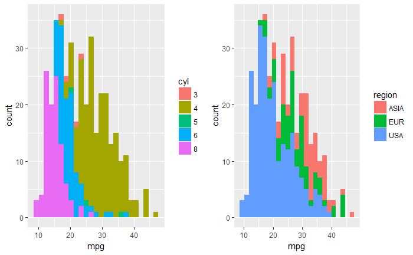

```r
h1 <- ggplot(auto, aes(x = mpg, fill = cyl)) + geom_histogram(bins = 25)
h2 <- ggplot(auto, aes(x = mpg, fill = region)) + geom_histogram(bins = 25)
grid.arrange(h1,h2, ncol = 2)
```

From the histograms above, we notice that cars with 4 cylinders from Asia and Europe are the most fuel efficient. We also notice that most 8-cylinder cars come from the USA. However, to give the most accurate conclusion, we need to take a more overall look.

Now let’s count the number of cars with different number of cylinders and different origins we have in our dataset.

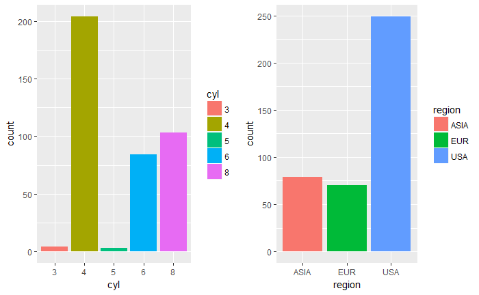

```r
h1 <- ggplot(auto, aes(x = cyl, fill = cyl)) + geom_bar()
h2 <- ggplot(auto, aes(x = region, fill = region)) + geom_bar()
grid.arrange(h1,h2, ncol = 2)
```

The number of cars with 4 cylinders is significantly greater cars with other number of cylinders, and the number of cars from USA manufacturer is also greater than cars from Europe and Asia.

Now we will take a look at the relationship between the number of cylinders in a car and its origin.

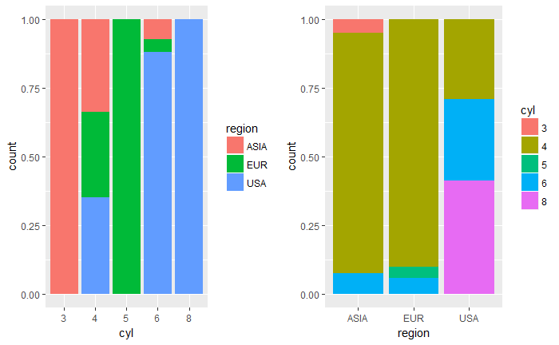

```r
h1 <- ggplot(auto, aes(x = cyl, fill = region)) + geom_bar(position = position_fill())
h2 <- ggplot(auto, aes(x = region, fill = cyl)) + geom_bar(position = position_fill())
grid.arrange(h1,h2, ncol = 2)
```

We notice that all 5-cylinder cars are from Europe, all 3-cylinder cars are from Asia and all 8-cylinder cars are from the USA. 1/3 of 4-cylinder cars are from the USA, Europe and Asia, equally. For 6-cylinder cars, most of them are from the USA. As for region, Asian and European cars are mostly 4-cylinders, while USA cars tend to have 8 cylinders.

Let’s take a look at the box plot for mpg by cyl and mpg by region to have another oveall look.

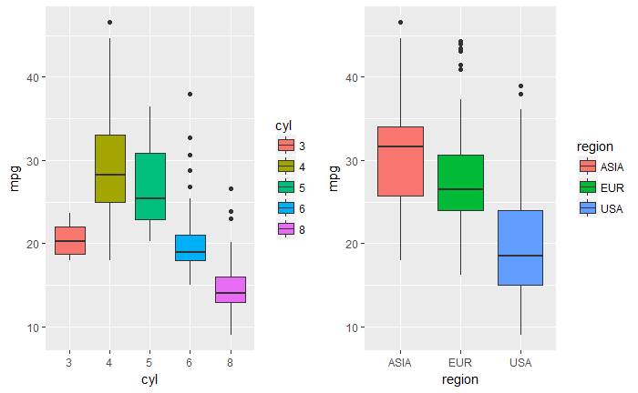

```r
h1 <- ggplot(auto, aes(x = cyl, y = mpg, fill = cyl)) + geom_boxplot()
h2 <- ggplot(auto, aes(x = region, y = mpg, fill = region)) + geom_boxplot()
grid.arrange(h1,h2, ncol = 2)
```

Since the box plot for 3, 6 and 8-cylinder cars are comparatively short, they suggest that cars have either 3, 6 and 8 cylinders tend to be least fuel efficient. Same for the region box plot, USA cars have the smallest mean of number of miles per gallon.

Next, we’re gonna take a look at the box plots for each number of cylinders in a car against its origin.

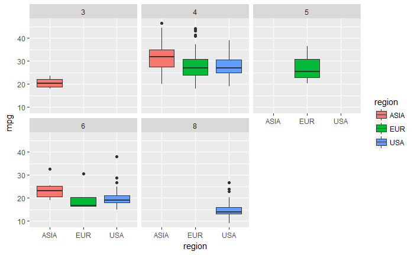

```r
h1 <- ggplot(auto, aes(x = region, y = mpg, fill = region)) + geom_boxplot()+ facet_wrap(~ cyl)
h1
```

We can see a clear relationship between how the number of cylinders in a car and its origin affect its mpg here. Cars with 4 cylinders have the highest median among others.

Let’s see if the car’s weight has any thing to do with mpg and its number of cylinders as well as origin.

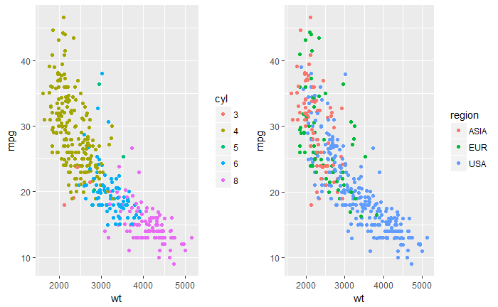

```r
h1 <- ggplot(auto, aes(x = wt, y = mpg, color = cyl)) + geom_jitter()
h2 <- ggplot(auto, aes(x = wt, y = mpg, color = region)) + geom_jitter()
grid.arrange(h1,h2, ncol = 2)
```

The graph on the left suggests that the more cylinders the car has, the more heavy it weighs, and the least fuel effciency that car has. The graph on the right also suggests that cars from USA tend to weigh more than cars from Asia and Europe, which mean they have more cylinders, and also mean they are less fuel efficient.

Let’s look at the details! Here’s a graph show the weight against mpg filtering by its origin.

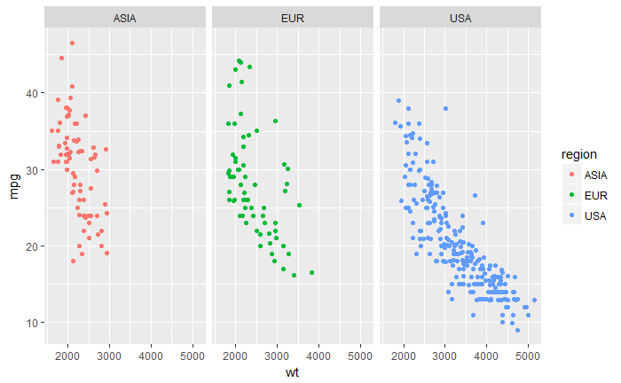

```r
h1 <- ggplot(auto, aes(x = wt, y = mpg, color = region)) + geom_jitter() + facet_wrap(~ region)
h1
```

Cars from Asia and Europe are clearly not as heavy as cars from the USA, which give them more miles per gallon.

Finally, a general graph of all the features we have been looking at: mpg, cylinders, weight and region.

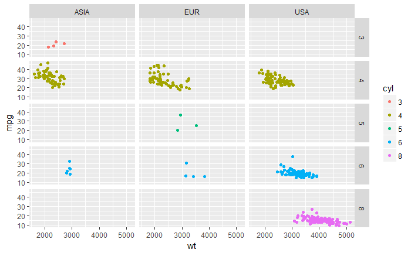

```r
h1 <- ggplot(auto, aes(x = wt, y = mpg, color = cyl)) + geom_jitter() + facet_grid(cyl ~ region)
h1
```

Asian cars with 4-cylinders are the most fuel efficient while USA cars with 8-cylinders are the least fuel efficient. The number of cylinders a car have and the manufacturing region affect the number of miles per gallon attained by a car. They also affect the car’s weight, which is another factor that change how the car’s fuel efficiency.